« Retour au Portfolio

# le_bonheur

```python
import pandas as pd
import matplotlib.pyplot as plt
import seaborn as sns
from scipy import stats

bonheur = pd.read_csv('enquete_sur_le_bonheur.csv', sep=';')
```

```python
bonheur.shape
```

```
(423, 20)
```

```python
bonheur.describe()
```

|  | Quel est votre âge ? (Ex : 30 pour 30 ans) | Dans quel département habitez-vous ? (Ex : 38 pour l'Isère / 0 si hors France) | Etes vous heureux ? | Vous épanouissez-vous dans votre travail ? | Accordez-vous de l'importance à l'argent ? | Etes-vous plutôt ville ou nature ? | Accordez-vous de l'importance à votre temps personnel ? | Accordez-vous de l'importance aux activités sportives ? | Accordez-vous de l'importance aux activités créatives ? | Prenez-vous soin de votre santé ? | Accordez-vous de l'importance à votre développement personnel ? |
| --- | --- | --- | --- | --- | --- | --- | --- | --- | --- | --- | --- |
| count | 423.000000 | 423.000000 | 423.000000 | 414.000000 | 423.000000 | 423.000000 | 423.000000 | 423.000000 | 423.000000 | 423.000000 | 423.000000 |
| mean | 34.621749 | 241.368794 | 3.926714 | 3.545894 | 3.340426 | 3.692671 | 4.172577 | 3.496454 | 3.063830 | 3.607565 | 3.673759 |
| std | 13.034722 | 3814.976911 | 0.832868 | 1.074273 | 0.974775 | 1.118614 | 0.913825 | 1.244652 | 1.278029 | 0.952492 | 1.065373 |
| min | 9.000000 | 0.000000 | 1.000000 | 1.000000 | 1.000000 | 1.000000 | 1.000000 | 1.000000 | 1.000000 | 1.000000 | 1.000000 |
| 25% | 24.000000 | 34.000000 | 3.000000 | 3.000000 | 3.000000 | 3.000000 | 4.000000 | 3.000000 | 2.000000 | 3.000000 | 3.000000 |
| 50% | 31.000000 | 38.000000 | 4.000000 | 4.000000 | 3.000000 | 4.000000 | 4.000000 | 4.000000 | 3.000000 | 4.000000 | 4.000000 |
| 75% | 43.500000 | 74.000000 | 4.000000 | 4.000000 | 4.000000 | 5.000000 | 5.000000 | 5.000000 | 4.000000 | 4.000000 | 5.000000 |
| max | 99.000000 | 78500.000000 | 5.000000 | 5.000000 | 5.000000 | 5.000000 | 5.000000 | 5.000000 | 5.000000 | 5.000000 | 5.000000 |

```python
bonheur.info()
bonheur.dtypes.value_counts()
```

```
<class 'pandas.core.frame.DataFrame'>
RangeIndex: 423 entries, 0 to 422
Data columns (total 20 columns):
 #   Column                                                                                                Non-Null Count  Dtype
---  ------                                                                                                --------------  -----
 0   Timestamp                                                                                             423 non-null    object
 1   Quel est votre sexe ?                                                                                 423 non-null    object
 2   Quel est votre âge ? (Ex : 30 pour 30 ans)                                                            423 non-null    int64
 3   Dans quel département habitez-vous ? (Ex : 38 pour l'Isère / 0 si hors France)                        423 non-null    int64
 4   Etes vous heureux ?                                                                                   423 non-null    int64
 5   Accordez-vous de l'importance à ... ? (Cochez si oui)                                                 423 non-null    object
 6   Vous épanouissez-vous dans votre travail ?                                                            414 non-null    float64
 7   Accordez-vous de l'importance à l'argent ?                                                            423 non-null    int64
 8   Etes-vous plutôt ville ou nature ?                                                                    423 non-null    int64
 9   Accordez-vous de l'importance à votre temps personnel ?                                               423 non-null    int64
 10  Accordez-vous de l'importance aux activités sportives ?                                               423 non-null    int64
 11  Accordez-vous de l'importance aux activités créatives ?                                               423 non-null    int64
 12  Prenez-vous soin de votre santé ?                                                                     423 non-null    int64
 13  Accordez-vous de l'importance à votre développement personnel ?                                       423 non-null    int64
 14  Quel était votre rêve d'enfant ?                                                                      422 non-null    object
 15  Si vous fermez les yeux et imaginez un endroit où vous vous sentez bien, comment le décririez-vous ?  423 non-null    object
 16  Que faites vous qui vous rende heureux pendant votre temps personnel ?                                423 non-null    object
 17  Qu'est ce qui vous rend heureux au quotidien ?                                                        423 non-null    object
 18  Quel est votre but dans la vie ?                                                                      423 non-null    object
 19  Qu'est-ce qu'être heureux selon vous ?                                                                423 non-null    object
dtypes: float64(1), int64(10), object(9)
memory usage: 66.2+ KB
```

```
int64      10
object      9
float64     1
Name: count, dtype: int64
```

```python
bonheur.duplicated().value_counts()
```

```
False    423
Name: count, dtype: int64
```

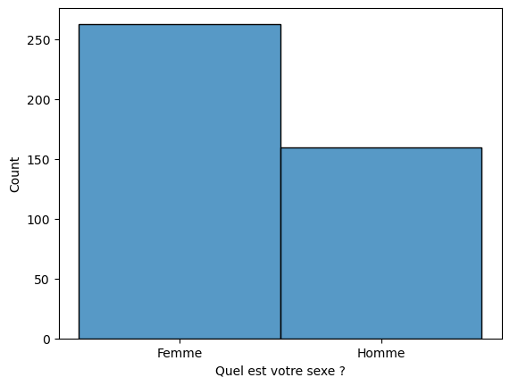

```python
sns.histplot(bonheur["Quel est votre sexe ?"])
```

```python
pd.crosstab(bonheur["Quel est votre sexe ?"],bonheur["Etes vous heureux ?"])
```

| Etes vous heureux ? Quel est votre sexe ? | 1 | 2 | 3 | 4 | 5 |
| --- | --- | --- | --- | --- | --- |
| Femme | 4 | 5 | 60 | 140 | 54 |
| Homme | 2 | 5 | 37 | 66 | 50 |

```python
bonheur.groupby(["Quel est votre sexe ?","Vous épanouissez-vous dans votre travail ?"]).count()
```

| Quel est votre sexe ? | Vous épanouissez-vous dans votre travail ? | Timestamp | Quel est votre âge ? (Ex : 30 pour 30 ans) | Dans quel département habitez-vous ? (Ex : 38 pour l'Isère / 0 si hors France) | Etes vous heureux ? | Accordez-vous de l'importance à ... ? (Cochez si oui) | Accordez-vous de l'importance à l'argent ? | Etes-vous plutôt ville ou nature ? | Accordez-vous de l'importance à votre temps personnel ? | Accordez-vous de l'importance aux activités sportives ? | Accordez-vous de l'importance aux activités créatives ? | Prenez-vous soin de votre santé ? | Accordez-vous de l'importance à votre développement personnel ? | Quel était votre rêve d'enfant ? | Si vous fermez les yeux et imaginez un endroit où vous vous sentez bien, comment le décririez-vous ? | Que faites vous qui vous rende heureux pendant votre temps personnel ? | Qu'est ce qui vous rend heureux au quotidien ? | Quel est votre but dans la vie ? | Qu'est-ce qu'être heureux selon vous ? |
| --- | --- | --- | --- | --- | --- | --- | --- | --- | --- | --- | --- | --- | --- | --- | --- | --- | --- | --- | --- |
| Femme | 1.0 | 13 | 13 | 13 | 13 | 13 | 13 | 13 | 13 | 13 | 13 | 13 | 13 | 13 | 13 | 13 | 13 | 13 | 13 |
|  | 2.0 | 20 | 20 | 20 | 20 | 20 | 20 | 20 | 20 | 20 | 20 | 20 | 20 | 20 | 20 | 20 | 20 | 20 | 20 |
|  | 3.0 | 79 | 79 | 79 | 79 | 79 | 79 | 79 | 79 | 79 | 79 | 79 | 79 | 79 | 79 | 79 | 79 | 79 | 79 |
|  | 4.0 | 103 | 103 | 103 | 103 | 103 | 103 | 103 | 103 | 103 | 103 | 103 | 103 | 103 | 103 | 103 | 103 | 103 | 103 |
|  | 5.0 | 40 | 40 | 40 | 40 | 40 | 40 | 40 | 40 | 40 | 40 | 40 | 40 | 40 | 40 | 40 | 40 | 40 | 40 |
| Homme | 1.0 | 12 | 12 | 12 | 12 | 12 | 12 | 12 | 12 | 12 | 12 | 12 | 12 | 12 | 12 | 12 | 12 | 12 | 12 |
|  | 2.0 | 18 | 18 | 18 | 18 | 18 | 18 | 18 | 18 | 18 | 18 | 18 | 18 | 18 | 18 | 18 | 18 | 18 | 18 |
|  | 3.0 | 32 | 32 | 32 | 32 | 32 | 32 | 32 | 32 | 32 | 32 | 32 | 32 | 32 | 32 | 32 | 32 | 32 | 32 |
|  | 4.0 | 63 | 63 | 63 | 63 | 63 | 63 | 63 | 63 | 63 | 63 | 63 | 63 | 62 | 63 | 63 | 63 | 63 | 63 |
|  | 5.0 | 34 | 34 | 34 | 34 | 34 | 34 | 34 | 34 | 34 | 34 | 34 | 34 | 34 | 34 | 34 | 34 | 34 | 34 |

```python
bonheur.groupby(["Quel est votre sexe ?","Vous épanouissez-vous dans votre travail ?"])["Quel est votre âge ? (Ex : 30 pour 30 ans)"].mean()
```

```
Quel est votre sexe ?  Vous épanouissez-vous dans votre travail ?
Femme                  1.0                                           46.153846
                       2.0                                           31.150000
                       3.0                                           32.746835
                       4.0                                           35.660194
                       5.0                                           33.875000
Homme                  1.0                                           30.333333
                       2.0                                           35.444444
                       3.0                                           29.843750
                       4.0                                           32.888889
                       5.0                                           35.911765
Name: Quel est votre âge ? (Ex : 30 pour 30 ans), dtype: float64
```

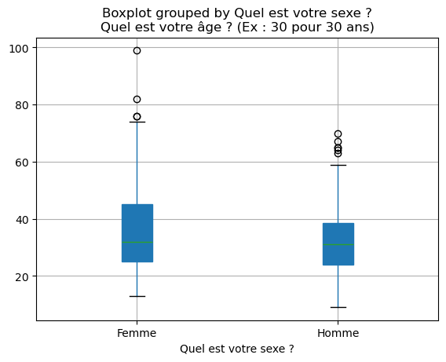

```python
box = bonheur.boxplot(column="Quel est votre âge ? (Ex : 30 pour 30 ans)",by='Quel est votre sexe ?', patch_artist=True)
```

```python
contingency_heureux_santé = pd.crosstab(bonheur["Etes vous heureux ?"], bonheur["Prenez-vous soin de votre santé ?"])
# Pour des donnée Qualitative
contingency_heureux_santé
```

| Prenez-vous soin de votre santé ? Etes vous heureux ? | 1 | 2 | 3 | 4 | 5 |
| --- | --- | --- | --- | --- | --- |
| 1 | 1 | 2 | 1 | 2 | 0 |
| 2 | 1 | 2 | 3 | 3 | 1 |
| 3 | 2 | 13 | 43 | 28 | 11 |
| 4 | 4 | 13 | 65 | 92 | 32 |
| 5 | 1 | 9 | 24 | 39 | 31 |

```python
#Test Qi 2

#HO : les 2 variable sont indépendante santé et heureux
#H1 : les variable ont un liens

stats.chi2_contingency(contingency_heureux_santé)
```

```
Chi2ContingencyResult(statistic=np.float64(43.34451922910196), pvalue=np.float64(0.000247937961823112), dof=16, expected_freq=array([[ 0.12765957,  0.55319149,  1.92907801,  2.32624113,  1.06382979],
       [ 0.21276596,  0.92198582,  3.21513002,  3.87706856,  1.77304965],
       [ 2.06382979,  8.94326241, 31.18676123, 37.60756501, 17.19858156],
       [ 4.38297872, 18.9929078 , 66.23167849, 79.86761229, 36.5248227 ],
       [ 2.21276596,  9.58865248, 33.43735225, 40.321513  , 18.43971631]]))
```

```python
# On convertit les colonnes de notes en nombres, les erreurs deviendront NaN
# for col in ['niveau_bonheur', 'soin_sante']:
#     df_clean[col] = pd.to_numeric(df_clean[col], errors='coerce')
```

```python
# --- Préparation des données (basée sur vos explorations) ---

# On renomme les colonnes pour simplifier le code
nouveaux_noms = {
    'Quel est votre sexe ?': 'sexe',
    'Quel est votre âge ? (Ex : 30 pour 30 ans)': 'age',
    'Etes vous heureux ?': 'niveau_bonheur',
    'Accordez-vous de l\'importance à ... ? (Cochez si oui)': 'piliers_importance',
    'Prenez-vous soin de votre santé ?': 'soin_sante'
}
# On ne garde que les colonnes utiles pour notre analyse
df_clean = bonheur[nouveaux_noms.keys()].rename(columns=nouveaux_noms)

df_clean
```

|  | sexe | age | niveau_bonheur | piliers_importance | soin_sante |
| --- | --- | --- | --- | --- | --- |
| 0 | Femme | 24 | 3 | Votre famille, Vos amis, Vos relations amoureu... | 2 |
| 1 | Femme | 22 | 4 | Votre famille, Vos amis, Vos relations amoureu... | 3 |
| 2 | Femme | 24 | 4 | Votre famille, Vos amis, Vos relations amoureu... | 5 |
| 3 | Femme | 30 | 4 | Votre famille, Vos amis, Vos relations amoureuses | 4 |
| 4 | Homme | 33 | 4 | Votre famille, Vos amis, Vos relations amoureuses | 3 |
| ... | ... | ... | ... | ... | ... |
| 418 | Femme | 29 | 4 | Votre famille, Vos amis, Vos relations amoureu... | 4 |
| 419 | Homme | 63 | 4 | Votre famille, Vos amis, Vos relations amoureuses | 4 |
| 420 | Femme | 21 | 3 | Votre famille, Vos amis, Vos relations amoureu... | 5 |
| 421 | Femme | 22 | 4 | Votre famille, Vos amis, Vos relations amoureu... | 3 |
| 422 | Femme | 21 | 3 | Votre famille, Vos amis, Vos relations amoureu... | 3 |

423 rows × 5 columns

```python
# On supprime les lignes avec des valeurs manquantes dans les colonnes clés
df_clean.dropna(subset=['niveau_bonheur', 'soin_sante', 'sexe'], inplace=True)
```

```python
print("Données nettoyées et prêtes pour les tests :")
df_clean.info()
```

```
Données nettoyées et prêtes pour les tests :
<class 'pandas.core.frame.DataFrame'>
RangeIndex: 423 entries, 0 to 422
Data columns (total 5 columns):
 #   Column              Non-Null Count  Dtype
---  ------              --------------  -----
 0   sexe                423 non-null    object
 1   age                 423 non-null    int64
 2   niveau_bonheur      423 non-null    int64
 3   piliers_importance  423 non-null    object
 4   soin_sante          423 non-null    int64
dtypes: int64(3), object(2)
memory usage: 16.7+ KB
```

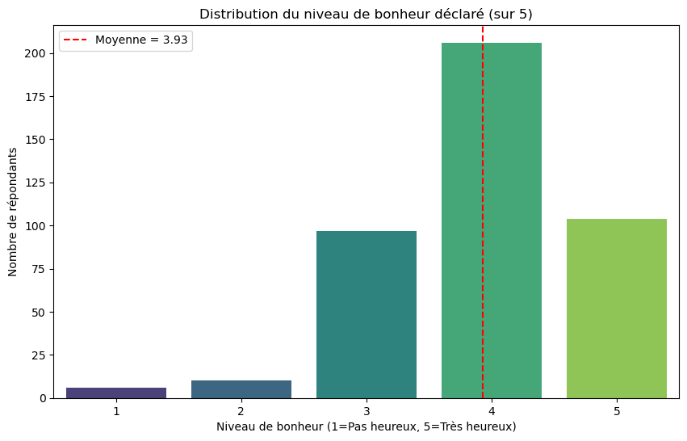

```python
note_moyenne = df_clean['niveau_bonheur'].mean()

plt.figure(figsize=(10, 6))
sns.countplot(x='niveau_bonheur', data=df_clean, palette='viridis')
plt.title("Distribution du niveau de bonheur déclaré (sur 5)")
plt.xlabel("Niveau de bonheur (1=Pas heureux, 5=Très heureux)")
plt.ylabel("Nombre de répondants")
plt.axvline(x=note_moyenne - 1, color='red', linestyle='--', label=f'Moyenne = {note_moyenne:.2f}')
plt.legend()
plt.show()
```

```python
note_moyenne = df_clean['niveau_bonheur'].mean()

print(f'la note moyenne est : {note_moyenne:.2f}')
```

```
la note moyenne est : 3.93
```

pour l'infographie : La note de bonheur la plus fréquente est 4/5, avec une moyenne générale de 3.9.

(Test d'hypothèse 1) : Prendre soin de sa santé rend-il plus heureux ? Approche pédagogique : Vous avez déjà réalisé ce test du Khi-deux (Chi-square). Il permet de vérifier si deux variables qualitatives (ici, le niveau de bonheur et le niveau de soin de sa santé) sont indépendantes.

**Hypothèse nulle (H0) :** Le niveau de bonheur est indépendant du soin apporté à sa santé.

**Hypothèse alternative (H1) :** Il existe un lien entre les deux

```python
# On recrée le tableau de contingence avec les données nettoyées
contingency_heureux_sante = pd.crosstab(df_clean["niveau_bonheur"], df_clean["soin_sante"])

contingency_heureux_sante
```

| soin_sante niveau_bonheur | 1 | 2 | 3 | 4 | 5 |
| --- | --- | --- | --- | --- | --- |
| 1 | 1 | 2 | 1 | 2 | 0 |
| 2 | 1 | 2 | 3 | 3 | 1 |
| 3 | 2 | 13 | 43 | 28 | 11 |
| 4 | 4 | 13 | 65 | 92 | 32 |
| 5 | 1 | 9 | 24 | 39 | 31 |

```python
# On réalise le test du Khi-deux
chi2, p_value, _, _ = stats.chi2_contingency(contingency_heureux_sante)

print(f"P-value du test du Khi-deux : {p_value:.5f}")
```

```
P-value du test du Khi-deux : 0.00025
```

pour l'infographie : Test statistique : Il existe un lien significatif entre le fait de prendre soin de sa santé et le niveau de bonheur déclaré.

(Test d'hypothèse 2) : Le bonheur a-t-il un genre ? Approche pédagogique : Pour notre deuxième test, nous allons comparer la moyenne de bonheur des hommes à celle des femmes pour voir si la différence est réelle ou due au hasard. Le test T de Student est parfait pour cela.

**Hypothèse nulle (H0) :** Il n'y a pas de différence de bonheur moyen entre les hommes et les femmes.

```python
# Séparer les échantillons
bonheur_hommes = df_clean[df_clean['sexe'] == 'Homme']['niveau_bonheur']
bonheur_femmes = df_clean[df_clean['sexe'] == 'Femme']['niveau_bonheur']

bonheur_hommes
bonheur_femmes
```

```
0      3
1      4
2      4
3      4
5      5
      ..
417    5
418    4
420    3
421    4
422    3
Name: niveau_bonheur, Length: 263, dtype: int64
```

```python
# Réaliser le test T
t_stat, p_value = stats.ttest_ind(bonheur_hommes, bonheur_femmes)

t_stat
```

```
np.float64(1.0505417403308015)
```

pour l'infographie : Test statistique : Le bonheur est partagé. Aucune différence significative n'a été mesurée entre les hommes et les femmes.

```python
bonheur['Accordez-vous de l\'importance à ... ? (Cochez si oui)']
```

```
0      Votre famille, Vos amis, Vos relations amoureu...
1      Votre famille, Vos amis, Vos relations amoureu...
2      Votre famille, Vos amis, Vos relations amoureu...
3      Votre famille, Vos amis, Vos relations amoureuses
4      Votre famille, Vos amis, Vos relations amoureuses
                             ...
418    Votre famille, Vos amis, Vos relations amoureu...
419    Votre famille, Vos amis, Vos relations amoureuses
420    Votre famille, Vos amis, Vos relations amoureu...
421    Votre famille, Vos amis, Vos relations amoureu...
422    Votre famille, Vos amis, Vos relations amoureu...
Name: Accordez-vous de l'importance à ... ? (Cochez si oui), Length: 423, dtype: object
```

```python
bonheur['Accordez-vous de l\'importance à ... ? (Cochez si oui)'].sort_values().count()
```

```
np.int64(423)
```

```python
# Insight 4 : Piliers de vie
piliers_importance = bonheur['Accordez-vous de l\'importance à ... ? (Cochez si oui)'].dropna().str.split(', ').explode().value_counts()

piliers_importance
```

```
Accordez-vous de l'importance à ... ? (Cochez si oui)
Votre famille                                 373
Vos amis                                      362
Vos relations amoureuses                      306
Vos relations sociales de manière générale    297
Name: count, dtype: int64
```

bonheur['...'] sélectionne la colonne d'intérêt.

.dropna() supprime les lignes avec des valeurs manquantes.

.str.split(', ') divise chaque chaîne de caractères restante de cette colonne en une liste de chaînes de caractères, en utilisant ', ' comme séparateur. Après cette étape, la colonne est une série où chaque entrée est une liste (par exemple, ['Famille', 'Santé']).

.explode() agit sur cette série :

Si une ligne contient la liste ['Famille', 'Santé'], elle sera transformée en deux lignes distinctes : une avec la valeur 'Famille' et une autre avec la valeur 'Santé'.

Si une ligne contenait la liste ['Carrière'], elle reste une seule ligne avec la valeur 'Carrière'.

**.explode()** dans ce code *L'objectif principal de .explode()* dans ce cas est de démultiplier les réponses multiples données dans un seul champ de texte, pour que chaque "pilier d'importance" (par exemple, "Famille," "Santé," "Argent") soit compté individuellement.

**Après .explode(),** la série est simplement une longue liste de chaque pilier mentionné par chaque répondant. Enfin, **.value_counts()** prend cette série "éclatée" et la transforme en un décompte de la fréquence d'apparition de chaque valeur unique. Cela permet de savoir combien de fois chaque pilier d'importance a été coché par les répondants, en fournissant le classement d'importance (le pilier le plus coché en premier).

pour l'infographie : La famille et les amis sont les deux piliers de vie les plus cités.

la fonction explode().value_counts()

```python
# Insight 5 : Satisfaction au travail
epanouissement_travail = bonheur['Vous épanouissez-vous dans votre travail ?'].dropna().mean()
print(f"\nNote moyenne d'épanouissement au travail : {epanouissement_travail:.2f} / 5")
```

```
Note moyenne d'épanouissement au travail : 3.55 / 5
```

pour l'infographie : La satisfaction au travail obtient une note moyenne de 3.55/5, montrant une marge de progression.